# Estimation of chronological age from methylation data

## Introduction

A general introduction to the topic can be found in these slides. However, for those who wish to understand the notebook in greater detail, the original [Horvath article (2013)](https://genomebiology.biomedcentral.com/articles/10.1186/gb-2013-14-10-r115) might be a useful reference.

## Goal of the analysis

The main objective of our analysis is to generate a relatively simple linear regression model which can predict a person's chronological age by observing the levels of DNA methylation in various genomic positions.

## Importing necessary python modules

The following analysis makes use of only five very basic python modules:

- `gzip` for dealing with gzipped files,
- `pandas` for manipulating tables and datafiles,
- `numpy` for basic mathematical calculations,
- `matplotlib` for plotting,
- `sklearn` for various linear regression models and related functions.

```python
import gzip
import pandas as pd
import numpy as np
import matplotlib.pyplot as plt
%matplotlib inline

#sklearn functions will be imported later on
```

## Downloading and preparing data files

**Note:** If you are short on time, you can skip this step and continue with the next phase of data analysis. However, in general, it is *very* important to have a good understanding of the data sources you are planning to investigate.

### Finding publicly available methylation data

One of the most widely used resources for publicly available methylation (and gene expression) data is [NCBI's Gene Expression Omnibus (GEO) database](https://www.ncbi.nlm.nih.gov/geo/). It takes a little practice to get familiar with the system, but the webpage allows you to search for epigenetic datasets by applying multiple filters.

In our case, besides obtaining the DNA methylation levels ($\beta$-values) for the patients in different genomic positions, it is also essential that the true chronological age of each person is available.

To this end, we will use the data from study `GSE41037`. According to the [GEO overview page](https://www.ncbi.nlm.nih.gov/geo/query/acc.cgi?acc=GSE41037) of the dataset, it contains the *blood* samples of 720 patients (with or without diagnosed schizophrenia) and methylation levels were determined on the *Illumina Infinium 27k Human Methylation Beadchip* measurement platform. This means that we have methylation $\beta$-values available in around 27 000 genomic positions for each patient.

### Downloading the data file

It is somewhat tricky to decide which datafile to download from the GEO website to obtain the most useful dataset. In general, whenever available, the "Series matrix files" of the studies contain the necessary information in the most condensed manner. For our specific case, this file can be downloaded from [here](https://ftp.ncbi.nlm.nih.gov/geo/series/GSE41nnn/GSE41037/matrix/) with the command below (on a Linux system):

`!wget https://ftp.ncbi.nlm.nih.gov/geo/series/GSE41nnn/GSE41037/matrix/GSE41037_series_matrix.txt.gz`

Or alternatively, on Windows, you can just click on the download link and download the file to your computer.

### Checking file structure

**It is always important to first simply take a look at your data files. To keep this tutorial adaptable to a Windows system, we use python functions for this task. However, if you are familiar with Linux Bash, alternatives are also presented.**

```python
# defining function to look into specific lines of a file
def head(filename, minrow = 0, maxrow=10):
    if ".gz" in filename:
        with gzip.open(filename, 'r') as f:
            lines = [f.readline().decode("utf-8") for line in range(1, maxrow+1)]
    else:
        with open(filename, 'r') as f:
            lines = [f.readline() for line in range(1, maxrow+1)]
    return lines[minrow:]

# defining function to search for specific strings in a file
def grep(filename, strings = []):
    if ".gz" in filename:
        with gzip.open(filename, 'r') as f:
            lines = []
            for l in f.readlines():
                if len(strings) == 0 or sum([s in l.decode("utf-8") for s in strings]) == len(strings):
                    lines.append(l.decode("utf-8"))
    else:
        with open(filename, 'r') as f:
            lines = []
            for l in f.readlines():
                if len(strings) == 0 or sum([s in l for s in strings]) == len(strings):
                    lines.append(l)
    return lines
```

Checking the first 10 rows of the datafile:

```python
head("GSE41037_series_matrix.txt.gz")
```

```
['!Series_title\t"Aging effects on DNA methylation modules in blood tissue"\n',
 '!Series_geo_accession\t"GSE41037"\n',
 '!Series_status\t"Public on Sep 21 2012"\n',
 '!Series_submission_date\t"Sep 20 2012"\n',
 '!Series_last_update_date\t"Oct 07 2019"\n',
 '!Series_pubmed_id\t"23034122"\n',
 '!Series_pubmed_id\t"25424713"\n',
 '!Series_pubmed_id\t"26949191"\n',
 '!Series_summary\t"Genome wide DNA methylation profiling of whole blood in schizophrenia patients and healthy subjects. The Illumina Infinium 27k Human DNA methylation Beadchip v1.2 was used to obtain DNA methylation profiles across approximately 27,000 CpGs. Raw data included 325 schizophrenia pat…
 '!Series_overall_design\t"Bisulphite converted DNA from 720 samples were hybridised to the Illumina Infinium 27k Human Methylation Beadchip [Publication: Horvath et al., Genome Biology, Special Edition]"\n']
```

The same thing in bash:

`!zcat GSE41037_series_matrix.txt.gz | head`

It seems that the first several lines of the file contain various metadata about the study and the investigated samples and start with an `!` character. Let's see where this structure changes (try varying `minrow` and `maxrow` to find where lines no longer start with `!`):

```python
head("GSE41037_series_matrix.txt.gz", minrow=72, maxrow=76)
```

```
['!Sample_data_row_count\t"27578"\t"27578"\t"27578"\t"27578"\t"27578"\t"27578"\t"27578"\t"27578"\t"27578"\t"27578"\t"27578"\t"27578"\t"27578"\t"27578"\t"27578"\t"27578"\t"27578"\t"27578"\t"27578"\t"27578"\t"27578"\t"27578"\t"27578"\t"27578"\t"27578"\t"27578"\t"27578"\t"27578"\t"27578"\t"27578"\t"275…
 '!series_matrix_table_begin\n',
 '"ID_REF"\t"GSM1007129"\t"GSM1007130"\t"GSM1007131"\t"GSM1007132"\t"GSM1007133"\t"GSM1007134"\t"GSM1007135"\t"GSM1007136"\t"GSM1007137"\t"GSM1007138"\t"GSM1007139"\t"GSM1007140"\t"GSM1007141"\t"GSM1007142"\t"GSM1007143"\t"GSM1007144"\t"GSM1007145"\t"GSM1007146"\t"GSM1007147"\t"GSM1007148"\t"GSM1007…
 '"cg00000292"\t0.8264516\t0.7860047\t0.8215686\t0.800461\t0.8469291\t0.8616085\t0.6818182\t0.7847366\t0.8267857\t0.7461269\t0.7730578\t0.8732802\t0.833377\t0.7920247\t0.8510685\t0.8210617\t0.7859882\t0.8427243\t0.8608845\t0.8202247\t0.8653586\t0.8463829\t0.817049\t0.8485364\t0.7792422\t0.8249351\t0…
```

After a while lines starting with `!` give way to lines starting with `cg[some_number]`, with a line `!series_matrix_table_begin\n` marking this boundary. These following lines contain the actual methylation data, with the methylation probe ID (`cg[some_number]`) in the first column and methylation $\beta$-values for each sample in the rest of the columns.

We can also see that fields are separated by `\t` characters (tabulators).

### Obtaining metadata from lines starting with `!`

The following few steps require that you both understand the structure of the datafile and you have a basic knowledge of string manipulation in python. Other kinds of metadata could be extracted from the file in a similar manner by slightly modifying the codes below.

#### Sample GEO accession ID

These will later act as sample identifiers.

```python
GEO_ids = grep("GSE41037_series_matrix.txt.gz", strings=["!Sample_geo_accession"])[0].replace('"', '').strip().split("\t")[1:]
```

#### Age

The chronological age of the patients. This will be the independent variable in our models.

```python
age_base = grep("GSE41037_series_matrix.txt.gz", strings=["age: "])[0].replace('"', '').strip().split("\t")[1:]
age = [int(a.split(": ")[1]) for a in age_base]
```

#### Gender

Gender is not strictly necessary for model building in our case, but we extract this information as an example of incorporating other kinds of metadata into our visualizations.

```python
gender_base = grep("GSE41037_series_matrix.txt.gz", strings=["gender: "])[0].replace('"', '').strip().split("\t")[1:]
gender = [g.split(": ")[1] for g in gender_base]
```

### Loading actual methylation levels

This step is by far easier than extracting metadata, because `pandas` can simply ignore lines starting with a specific character (`!` in our case) if we set `comment = !`. It's also useful that we already know that columns are separated by the `\t` character, as we need to set this parameter for the `read_csv()` function.

```python
methylation_data = pd.read_csv("GSE41037_series_matrix.txt.gz", sep="\t", comment="!")
```

Let's peek into the table:

```python
methylation_data.head()
```

|  | ID_REF | GSM1007129 | GSM1007130 | GSM1007131 | GSM1007132 | GSM1007133 | GSM1007134 | GSM1007135 | GSM1007136 | GSM1007137 | ... | GSM1007839 | GSM1007840 | GSM1007841 | GSM1007842 | GSM1007843 | GSM1007844 | GSM1007845 | GSM1007846 | GSM1007847 | GSM1007848 |
| --- | --- | --- | --- | --- | --- | --- | --- | --- | --- | --- | --- | --- | --- | --- | --- | --- | --- | --- | --- | --- | --- |
| 0 | cg00000292 | 0.826452 | 0.786005 | 0.821569 | 0.800461 | 0.846929 | 0.861608 | 0.681818 | 0.784737 | 0.826786 | ... | 0.800676 | 0.782873 | 0.675258 | 0.789442 | 0.629310 | 0.756856 | 0.753206 | 0.743481 | 0.739643 | 0.773988 |
| 1 | cg00002426 | 0.664997 | 0.776752 | 0.718688 | 0.773340 | 0.760058 | 0.794964 | 0.723584 | 0.742225 | 0.746415 | ... | 0.783468 | 0.682987 | 0.792201 | 0.793917 | 0.755901 | 0.771837 | 0.787029 | 0.791851 | 0.808165 | 0.816977 |
| 2 | cg00003994 | 0.044991 | 0.065413 | 0.037126 | 0.047140 | 0.031929 | 0.057937 | 0.068399 | 0.057447 | 0.064459 | ... | 0.069613 | 0.080460 | 0.064493 | 0.056075 | 0.087791 | 0.062281 | 0.081177 | 0.064447 | 0.060761 | 0.061161 |
| 3 | cg00005847 | 0.157715 | 0.194652 | 0.202437 | 0.176671 | 0.146927 | 0.156609 | 0.147871 | 0.132038 | 0.086012 | ... | 0.255437 | 0.208387 | 0.233601 | 0.177870 | 0.219735 | 0.190101 | 0.193621 | 0.182563 | 0.164809 | 0.171088 |
| 4 | cg00006414 | 0.077353 | 0.091298 | 0.080609 | 0.107725 | 0.130279 | 0.098889 | 0.117026 | 0.093538 | 0.122043 | ... | 0.095717 | 0.115239 | 0.094053 | 0.063734 | 0.074883 | 0.066782 | 0.072243 | 0.070335 | 0.075786 | 0.077058 |

5 rows × 721 columns

Let's check if data dimensions are consistent:

```python
methylation_data.shape
```

```
(27578, 721)
```

Methylation data is available for 27578 genomic positions (in line with our previous assumption based on the measurement platform) and for 720 samples (the first column is the probe identifier).

```python
len(GEO_ids), len(age), len(gender)
```

```
(720, 720, 720)
```

Metadata lists also have 720 elements. (Yay!)

### Saving condensed datatable for later use

It is practical to now save our datatable in a straightforward format, so that we don't have to rerun metadata extraction if we wish to work on it later on.

First we transpose the data matrix and then add appropriate metadata to additional columns.

```python
# setting the index to be probe IDs
methylation_data.index = methylation_data["ID_REF"]
# dropping the probe ID column as it's already present as the index
methylation_data = methylation_data[methylation_data.columns[1:]]

# transposing the dataframe, so each row now corresponds with a sample and each column with a probe
# with measurement beta-values in each cell
methylation_data = methylation_data.transpose()

# adding the chronological age as an additional column
methylation_data["age"] = [age[GEO_ids.index(k)] for k in methylation_data.index]

# adding gender as an additional column
methylation_data["gender"] = [gender[GEO_ids.index(k)] for k in methylation_data.index]

# finally saving the resulting datatable for later use
methylation_data.to_csv("clean_data.csv")
```

## Basic data exploration

### Loading cleaned data - optional

**If you have skipped the previous section of data cleaning**, load the clean data file with:

```python
methylation_data = pd.read_csv("http://pipeko.web.elte.hu/dataScienceLeiden2022/clean_data.csv", index_col=0)
```

Checking dataframe structure:

```python
methylation_data.head()
```

|  | cg00000292 | cg00002426 | cg00003994 | cg00005847 | cg00006414 | cg00007981 | cg00008493 | cg00008713 | cg00009407 | cg00010193 | ... | cg27655855 | cg27655905 | cg27657249 | cg27657283 | cg27661264 | cg27662379 | cg27662877 | cg27665659 | age | gender |
| --- | --- | --- | --- | --- | --- | --- | --- | --- | --- | --- | --- | --- | --- | --- | --- | --- | --- | --- | --- | --- | --- |
| GSM1007129 | 0.826452 | 0.664997 | 0.044991 | 0.157715 | 0.077353 | 0.096471 | 0.962778 | 0.029778 | 0.021056 | 0.827150 | ... | 0.851430 | 0.082630 | 0.102691 | 0.081038 | 0.197167 | 0.034734 | 0.077491 | 0.028459 | 34 | male |
| GSM1007130 | 0.786005 | 0.776752 | 0.065413 | 0.194652 | 0.091298 | 0.062367 | 0.959261 | 0.027133 | 0.027462 | 0.563721 | ... | 0.851926 | 0.061912 | 0.113114 | 0.111551 | 0.377573 | 0.039018 | 0.059095 | 0.023167 | 31 | male |
| GSM1007131 | 0.821569 | 0.718688 | 0.037126 | 0.202437 | 0.080609 | 0.046132 | 0.951115 | 0.028917 | 0.025956 | 0.717970 | ... | 0.837107 | 0.090011 | 0.081595 | 0.101114 | 0.272153 | 0.058072 | 0.110436 | 0.028143 | 23 | male |
| GSM1007132 | 0.800461 | 0.773340 | 0.047140 | 0.176671 | 0.107725 | 0.065258 | 0.969159 | 0.036551 | 0.026302 | 0.784856 | ... | 0.846224 | 0.071743 | 0.114577 | 0.070997 | 0.341921 | 0.049498 | 0.076674 | 0.029572 | 31 | male |
| GSM1007133 | 0.846929 | 0.760058 | 0.031929 | 0.146927 | 0.130279 | 0.057724 | 0.952163 | 0.028230 | 0.023117 | 0.478455 | ... | 0.843953 | 0.102713 | 0.097607 | 0.097285 | 0.270388 | 0.029971 | 0.056054 | 0.034285 | 23 | male |

5 rows × 27580 columns

The cleaned dataset has the following properties:

- each row represents a sample with the sample ID in the index of the dataframe,
- most of the columns (except the last two) have a name of `cg[some_number]`, which are the methylation probe identifiers,
- cells contain the methylation $\beta$-values measured at a given probe in a given sample,
- there are two additional columns at the end:
  - age: chronological age of the patient, the independent variable in our models,
  - gender: the gender of the patient which will only be used in visualizations.

### Checking age distribution

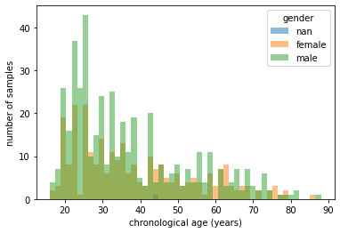

```python
methylation_data.pivot(columns="gender", values="age").plot.hist(bins=50, alpha=0.5)
plt.xlabel("chronological age (years)")
plt.ylabel("number of samples");
```

It seems that we have a relatively wide age distribution in our dataset, even if a little biased to younger ages. This means that the model we build on this data has a decent chance to capture the peculiarities of all age groups. Also, there is no huge difference between the age distributions of different the genders, thus it is unlikely that our model would implicitly learn the gender of a patient instead of his/her age. Additionally, there are a few samples for which gender is unknown, but given that it is only used for visualization purposes, this is not a real problem.

### Checking $\beta$-value distribution

This would take a lot of time to run on all the probes, so we are randomly selecting N of them.

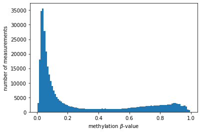

```python
probe_columns = [c for c in methylation_data.columns if c[:2]=="cg"]
N = 500
plt.hist(np.array(methylation_data[np.random.choice(probe_columns, size=N,
                                                    replace=False)]).reshape(methylation_data.shape[0]*N),
         bins=100);
plt.xlabel(r'methylation $\beta$-value')
plt.ylabel("number of measurements");
```

The $\beta$-value distribution is indeed confined to the (0,1) range, with most of the measurements suggesting non-methylated cytosines in the genome and with a smaller peak around 0.9 (implying methylated positions). This is in line with typical distribution curves for methylation $\beta$-values.

### Checking for missing values

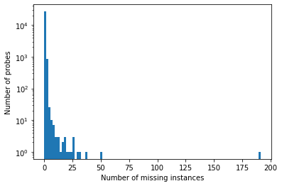

```python
plt.hist(methylation_data[probe_columns].isnull().sum(axis=0), bins=100)
plt.xlabel("Number of missing instances")
plt.ylabel("Number of probes")
# using logarithmic y-axis to get a more easily interpretable figure
plt.yscale("log");
```

Apparently, most of the probes have zero missing values throughout all samples and there are only a few (exactly 20, see below) of them that are missing from more than 10 samples. We preemptively filter these out prior to further analysis.

```python
# number of probes with more than 10 missing values
(methylation_data[probe_columns].isnull().sum(axis=0) > 10).sum()
```

```
20
```

```python
# filtering out probes with more than 10 missing values
probe_cols_to_keep = np.array(probe_columns)[list((methylation_data[probe_columns].isnull().sum(axis=0) <= 10)[probe_columns])]
methylation_data = methylation_data[list(probe_cols_to_keep) + ["age", "gender"]]
methylation_data.shape
```

```
(720, 27560)
```

There are multiple ways to deal with the remaining missing values. In many cases, you can simply replace them with a fixed value. Other times, it might be more practical to replace missing values either with the average methylation in the given sample or the average methylation of the given probe across all samples. The latter solution, however, depends on the dataset you are investigating.

In our specific case, missing values will be simply replaced with zero.

```python
methylation_data[probe_cols_to_keep] = methylation_data[probe_cols_to_keep].fillna(0)
```

## Age transformation

To understand the detailed reasoning behind this step, consult the original [Horvath article (2013)](https://genomebiology.biomedcentral.com/articles/10.1186/gb-2013-14-10-r115).

Given that "DNA methylation age" is not a linear function of chronological age, but changes more rapidly below around 20 years and slowly saturates after that, it is reasonable to perform a simple (and invertible) transformation of age prior to model fitting. Thus, the target variable in our following analyses is not simply the chronological age, but its transformed version.

The following two functions can be used to transform between the two variables:

```python
def transform_age(a, adult_age = 20):
    x = (a+1)/(1+adult_age)
    return np.where(x <= 1, np.log(x), x-1)

def retransform_age(x, adult_age = 20):
    return np.where(x < 0, (1+adult_age)*np.exp(x)-1, (1+adult_age)*x+adult_age)
```

```python
# checking if consistent
a = 15
retransform_age(transform_age(a)) == a
```

```
True
```

Now we add a column to the dataframe containing transformed ages:

```python
methylation_data["age_transf"] = methylation_data["age"].apply(transform_age)
```

## Preparations for model fitting

### Train-test split

Whenever you wish to fit models to a dataset, it is useful to separate a part of it which can be later used for performance assessment and is somewhat independent of the data that you use for model fitting. However, always keep in mind that the true test of a model has to be performed on a *completely unrelated* dataset. It is possible that experimental and technical artifacts are highly correlated in a dataset measured at the same time, on the same instrument, with the same pipeline. This means that even if you separate a part of it for later testing, some information about these samples inherently "seep through" to the training set and the model learns these artifacts instead of real trends. This would result in very high performance metrics on the training and test sets but very low on an independent validation set.

```python
from sklearn.model_selection import train_test_split
```

```python
# splitting data into training and test sets
X_LR_train, X_LR_test, y_LR_train, y_LR_test = train_test_split(methylation_data[probe_cols_to_keep],
                                                                methylation_data["age_transf"],
                                                                test_size=0.33, random_state=42)
```

### Standardization of methylation data

It is a general practice in machine learning tasks to rescale the input parameters in a way that "they are on the same scale". For example, if you want to include both the height of a person (measured in cm) and the thickness of their nail (measured in mm) in the same model, the effect of height would "overpower" the effect of nail thickness in a numerical model simply because its values have an average around 160-170 (cm), while nail thickness is around 0.4-0.5 (mm).

In our case, methylation $\beta$-values are relatively similar in the sense that they all fall into the (0,1) range. However, it is still useful to perform the rescaling prior to model building.

One of the most widely used rescaling techniques is ["standardization"](https://scikit-learn.org/stable/modules/generated/sklearn.preprocessing.StandardScaler.html#sklearn.preprocessing.StandardScaler), which calculates the $\mu$ mean and $\sigma$ standard deviation for each input parameter and transforms the values with the following formula:

$$\tilde{x} = \frac{x-\mu}{\sigma}$$

This results in transformed variables with zero mean and a standard deviation of 1.

**Note:** standardization is first performed on the training set and the transformed variables are used for model building. However, when you test your model on a test set or an unrelated validation set, be sure to standardize their input parameters based on the original training set and not on themselves.

```python
from sklearn.preprocessing import StandardScaler
```

```python
# standardization
scaler = StandardScaler()

# standardization is based on the input parameters of the training set
# (mean and standard deviation is calculated on these samples)
scaler.fit(X_LR_train)

# the actual transformation is performed on both sets of input parameters
X_LR_train = scaler.transform(X_LR_train)
X_LR_test = scaler.transform(X_LR_test)
```

## Model fitting

### Simple linear regression

As a first step, we are going to fit a simple linear regression model to our dataset. Given that in this case, there are **no tunable hyperparameters** to be determined via cross-validation, we simply find the best model on a training dataset using the "ordinary least squares method" and access its performance on a test set. This is fairly straightforward with the built-in functions of `sklearn`.

For a summary on the linear models of the `sklearn` package, check out [this site](https://scikit-learn.org/stable/modules/linear_model.html).

```python
from sklearn import linear_model
```

#### Model

```python
# creating model object
LR = linear_model.LinearRegression()

# training the model on the training sets
LR.fit(X_LR_train, y_LR_train)

# making predictions on the test set
y_LR_test_predicted_transf = LR.predict(X_LR_test)

# transforming predicted ages to actual chronological age scales
y_LR_test_predicted = retransform_age(y_LR_test_predicted_transf)
```

#### Predictions on training and test sets

Visually checking predictions:

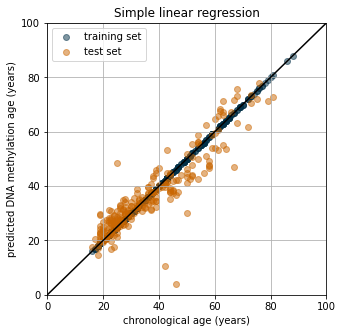

```python
plt.figure(figsize=(5,5))
plt.subplot(1, 1, 1)
plt.scatter(retransform_age(y_LR_train), retransform_age(LR.predict(X_LR_train)), color="#023047",
            alpha=0.5, label="training set")
plt.scatter(retransform_age(y_LR_test), retransform_age(y_LR_test_predicted_transf), color="#ca6702",
            alpha=0.5, label="test set")
plt.xlim(0,100)
plt.ylim(0,100)
plt.grid()
plt.xlabel("chronological age (years)")
plt.ylabel("predicted DNA methylation age (years)")
plt.title("Simple linear regression")
plt.plot([0,100], [0,100], color="black")
plt.legend()
plt.show()
```

The method seems to have *fitted a perfect model to the training data*. This is somewhat worrisome, as this generally implies **overfitting**. Given that we had more than 27 thousand input parameters for less than 500 samples, this seems extremely likely. However, the predictions on the test set are promising at first glance, but it is still useful to access model performance by calculating some metrics. Given that the original [Horvath article (2013)](https://genomebiology.biomedcentral.com/articles/10.1186/gb-2013-14-10-r115) uses MAE (median absolute error) and the Pearson-correlation coefficient for this, we are going to stick with the same approach:

```python
print("------- Training set -------")
print("MAE (median absolute error): %.2f years" %
      np.median(np.abs(retransform_age(y_LR_train)-retransform_age(LR.predict(X_LR_train)))))
print("Pearson-correlation coefficient: %.2f" %
      np.corrcoef(retransform_age(y_LR_train), retransform_age(LR.predict(X_LR_train)))[0,1])
print()
print("------- Test set -------")
print("MAE (median absolute error): %.2f years" %
      np.median(np.abs(retransform_age(y_LR_test)-retransform_age(y_LR_test_predicted_transf))))
print("Pearson-correlation coefficient: %.2f" %
      np.corrcoef(retransform_age(y_LR_test), retransform_age(y_LR_test_predicted_transf))[0,1])
```

```
------- Training set -------
MAE (median absolute error): 0.00 years
Pearson-correlation coefficient: 1.00

------- Test set -------
MAE (median absolute error): 3.15 years
Pearson-correlation coefficient: 0.91
```

#### Predictions on a validation set

Now let's check if our model performs well on an unrelated dataset. Here we are going to load another GEO study (accession GSE19711) prepared the same way as our original data.

```python
validation_data = pd.read_csv("http://pipeko.web.elte.hu/dataScienceLeiden2022/validation_dataset.csv", index_col=0)
```

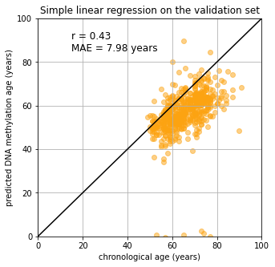

```python
# creating input array for validation dataset by selecting only those probes that were kept in the model
# and replacing missing values with zeros
X_LR_validation = validation_data[probe_cols_to_keep].fillna(0)
# rescaling validation data with the parameters learned on the training set
X_LR_validation = scaler.transform(X_LR_validation)

# now we can actually run the prediction and access model performance
y_LR_validation_predicted_transf = LR.predict(X_LR_validation)

MAE = np.median(np.abs(validation_data["age"]-retransform_age(y_LR_validation_predicted_transf)))
R = np.corrcoef(validation_data["age"], retransform_age(y_LR_validation_predicted_transf))[0,1]

plt.figure(figsize=(5,5))
plt.subplot(1, 1, 1)
plt.scatter(validation_data["age"], retransform_age(y_LR_validation_predicted_transf), color="#fca311", alpha=0.5)
plt.xlim(0,100)
plt.ylim(0,100)
plt.grid()
plt.xlabel("chronological age (years)")
plt.ylabel("predicted DNA methylation age (years)")
plt.title("Simple linear regression on the validation set")
plt.plot([0,100], [0,100], color="black")
plt.annotate("r = %.2f\nMAE = %.2f years" % (R, MAE), xy=(15,85), fontsize=12)
plt.show()
```

Both the correlation and the MAE seems to be way worse on an unrelated validation dataset than on the original one. To some extent, this is always to be expected. Given however, that our model was a perfect fit to the training set, it is reasonable to assume that the lack of generalization is due to overfitting.

The number of non-zero coefficients in our model can be determined with:

```python
(np.abs(LR.coef_) > 0).sum()
```

```
27558
```

### ElasticNet regression - linear regression with L1 and L2-regularization

To compensate for overfitting, we add the L1 and L2-norm of the coefficient vector to the objective function with different multipliers and try to find the optimal value of these hyperparameters by minimizing the objective function using cross-validation.

During cross-validation, additional train-test splits and model fittings are performed multiple times on the training dataset to get statistics on performance metrics. Finally, those hyperparameters are chosen that resulted in the "best" model. (Model selection is not a trivial question, you can learn about the approach in a specific setting [here](https://scikit-learn.org/stable/auto_examples/linear_model/plot_lasso_lars_ic.html).)

#### Model

Even though this sounds incredibly complicated, the whole method is implemented in a [simple function](https://scikit-learn.org/stable/modules/generated/sklearn.linear_model.ElasticNetCV.html#sklearn.linear_model.ElasticNetCV):

```python
LR_elnet = linear_model.ElasticNetCV()
LR_elnet.fit(X_LR_train, y_LR_train)
```

```
ElasticNetCV()
```

Now let's see right away the number of non-zero coefficients in the resulting model:

```python
(np.abs(LR_elnet.coef_) > 0).sum()
```

```
250
```

This seems to be promising in terms of avoiding overfitting.

#### Predictions on training and test sets

Visually checking predictions:

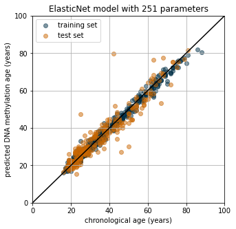

```python
plt.figure(figsize=(5,5))
plt.subplot(1, 1, 1)
plt.scatter(retransform_age(y_LR_train), retransform_age(LR_elnet.predict(X_LR_train)), color="#023047",
            alpha=0.5, label="training set")
plt.scatter(retransform_age(y_LR_test), retransform_age(LR_elnet.predict(X_LR_test)), color="#ca6702",
            alpha=0.5, label="test set")
plt.xlim(0,100)
plt.ylim(0,100)
plt.grid()
plt.xlabel("chronological age (years)")
plt.ylabel("predicted DNA methylation age (years)")
plt.title('ElasticNet model with %d parameters' % ((np.abs(LR_elnet.coef_) > 0).sum()+1))
plt.plot([0,100], [0,100], color="black")
plt.legend()
plt.show()
```

As expected, the 251-parameter model cannot perfectly fit to the original training data, but predictions seem to be generally good on both the training and test sets.

```python
print("------- Training set -------")
print("MAE (median absolute error): %.2f years" %
      np.median(np.abs(retransform_age(y_LR_train)-retransform_age(LR_elnet.predict(X_LR_train)))))
print("Pearson-correlation coefficient: %.2f" %
      np.corrcoef(retransform_age(y_LR_train), retransform_age(LR_elnet.predict(X_LR_train)))[0,1])
print()
print("------- Test set -------")
print("MAE (median absolute error): %.2f years" %
      np.median(np.abs(retransform_age(y_LR_test)-retransform_age(LR_elnet.predict(X_LR_test)))))
print("Pearson-correlation coefficient: %.2f" %
      np.corrcoef(retransform_age(y_LR_test), retransform_age(LR_elnet.predict(X_LR_test)))[0,1])
```

```
------- Training set -------
MAE (median absolute error): 1.23 years
Pearson-correlation coefficient: 0.99

------- Test set -------
MAE (median absolute error): 2.52 years
Pearson-correlation coefficient: 0.94
```

**Note that even though training performance is worse than when using simple linear regression, the test performance has markedly improved!**

#### Predictions on a validation set

Now let's check how our model performs on the validation dataset used above.

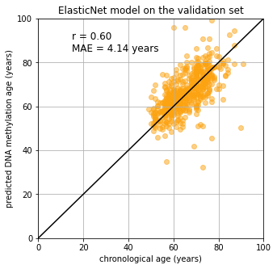

```python
# running the prediction and accessing model performance
y_LR_validation_predicted_transf = LR_elnet.predict(X_LR_validation)

MAE = np.median(np.abs(validation_data["age"]-retransform_age(y_LR_validation_predicted_transf)))
R = np.corrcoef(validation_data["age"], retransform_age(y_LR_validation_predicted_transf))[0,1]

plt.figure(figsize=(5,5))
plt.subplot(1, 1, 1)
plt.scatter(validation_data["age"], retransform_age(y_LR_validation_predicted_transf), color="#fca311", alpha=0.5)
plt.xlim(0,100)
plt.ylim(0,100)
plt.grid()
plt.xlabel("chronological age (years)")
plt.ylabel("predicted DNA methylation age (years)")
plt.title("ElasticNet model on the validation set")
plt.plot([0,100], [0,100], color="black")
plt.annotate("r = %.2f\nMAE = %.2f years" % (R, MAE), xy=(15,85), fontsize=12)
plt.show()
```

Both the correlation and the MAE is significantly better in this case than for the simple linear regression model! It is also worth noting that while the previous linear regression model predicted an age of around zero for a bunch of patients aged between 50-80, this is not the case for this model.

## Comparison with the Horvath epigenetic clock

Let's compare our results with the performance of the original Horvath epigenetic clock.

You can download [Additional file 3](https://static-content.springer.com/esm/art%3A10.1186%2Fgb-2013-14-10-r115/MediaObjects/13059_2013_3156_MOESM3_ESM.csv) from the [article website](https://genomebiology.biomedcentral.com/articles/10.1186/gb-2013-14-10-r115) which contains the coefficients of the original Horvath model. We are going to load it into a dataframe with (**always look into the file so you can set the appropriate parameters for loading**):

```python
head("horvath_additionalfile3.csv", maxrow=5)
```

```
['"These coefficient values relate CpGs to a transformed version of age, i.e. the linear combination of CpGs needs to be suitably transformed.",,,,,,,,,,,,,,,,,,,,,,\n',
 ',,,,,,,,,,,,,,,,,,,,,,\n',
 'CpGmarker,CoefficientTraining,CoefficientTrainingShrunk,varByCpG,minByCpG,maxByCpG,medianByCpG,medianByCpGYoung,medianByCpGOld,Gene_ID,GenomeBuild,Chr,MapInfo,SourceVersion,TSS_Coordinate,Gene_Strand,Symbol,Synonym,Accession,GID,Annotation,Product,Marginal Age Relationship\n',
 '(Intercept),0.695507258,0.886919795,NA,NA,NA,NA,NA,NA,,,,,,,,,,,,,,\n',
 'cg00075967,0.12933661,0.108096063,0.026,0.016,0.97,0.75,0.72,0.75,64220,36,15,72282407,36.1,72282245,-,STRA6,PP14296; FLJ12541; ,NM_022369.2,GI:21314699,synonyms: PP14296; FLJ12541,stimulated by retinoic acid gene 6 homolog,positive\n']
```

```python
# I only know that the first two rows need to be ignored because I've checked how the file looks like
horvath_model_coeffs = pd.read_csv("horvath_additionalfile3.csv", skiprows=2)
print(horvath_model_coeffs.shape)
horvath_model_coeffs.head()
```

```
(354, 23)
```

|  | CpGmarker | CoefficientTraining | CoefficientTrainingShrunk | varByCpG | minByCpG | maxByCpG | medianByCpG | medianByCpGYoung | medianByCpGOld | Gene_ID | ... | SourceVersion | TSS_Coordinate | Gene_Strand | Symbol | Synonym | Accession | GID | Annotation | Product | Marginal Age Relationship |
| --- | --- | --- | --- | --- | --- | --- | --- | --- | --- | --- | --- | --- | --- | --- | --- | --- | --- | --- | --- | --- | --- |
| 0 | (Intercept) | 0.695507 | 0.886920 | NaN | NaN | NaN | NaN | NaN | NaN | NaN | ... | NaN | NaN | NaN | NaN | NaN | NaN | NaN | NaN | NaN | NaN |
| 1 | cg00075967 | 0.129337 | 0.108096 | 0.02600 | 0.0160 | 0.97 | 0.750 | 0.720 | 0.750 | 64220.0 | ... | 36.1 | 72282245.0 | - | STRA6 | PP14296; FLJ12541; | NM_022369.2 | GI:21314699 | synonyms: PP14296; FLJ12541 | stimulated by retinoic acid gene 6 homolog | positive |
| 2 | cg00374717 | 0.005018 | NaN | 0.01200 | 0.0031 | 1.00 | 0.890 | 0.870 | 0.900 | 22901.0 | ... | 36.1 | 63815191.0 | + | ARSG | KIAA1001; | NM_014960.2 | GI:45430056 | go_function: hydrolase activity; go_function: ... | Arylsulfatase G | positive |
| 3 | cg00864867 | 1.599764 | 1.863969 | 0.00087 | 0.0000 | 0.58 | 0.049 | 0.045 | 0.053 | 5074.0 | ... | 36.1 | 78608921.0 | - | PAWR | PAR4; Par-4; | NM_002583.2 | GI:55769532 | ##############################################... | PRKC; apoptosis; WT1; regulator | positive |
| 4 | cg00945507 | 0.056852 | NaN | 0.01600 | 0.0000 | 0.96 | 0.240 | 0.230 | 0.250 | 23480.0 | ... | 36.1 | 54794433.0 | - | SEC61G | SSS1; | NM_014302.3 | GI:60279263 | ##############################################... | Sec61 gamma subunit | positive |

5 rows × 23 columns

The first column contains the probe IDs (and the intercept) and coefficients are located in the second column. Based on the size of the datatable, the original Horvath model contains 353 coefficients and the intercept.

Keep in mind that the coefficients presented here are to be used on non-standardized data. (For details, see how the [glmnet() function works in R](https://www.rdocumentation.org/packages/glmnet/versions/4.1-3/topics/glmnet), which was used to train the Horvath model.)

Now we need to manually calculate the predicted ages from the coefficients without an appropriate `predict()` method. This is pretty straightforward though, given that we basically have to calculate a weighted average of the relevant methylation values. There are much more time-efficient ways to do this (see [matrix multiplication with `numpy`](https://numpy.org/doc/stable/reference/generated/numpy.matmul.html) for details), but the function below provides a didactic solution.

```python
def get_horvath_prediction(r):
    pred = 0
    for pi, probe in enumerate(list(horvath_model_coeffs["CpGmarker"][1:])): # skipping intercept
        if pd.isnull(r[probe]): # if no methylation value is present for the probe, treat it as zero
            continue
        pred += r[probe]*horvath_model_coeffs["CoefficientTraining"][pi+1]
    pred += horvath_model_coeffs["CoefficientTraining"][0] # now adding the intercept
    return float(retransform_age(pred)) # transforming prediction
```

```python
validation_data["horvath_prediction"] = validation_data.apply(get_horvath_prediction, axis=1)
```

Checking performance:

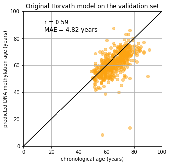

```python
MAE = np.median(np.abs(validation_data["age"]-validation_data["horvath_prediction"]))
R = np.corrcoef(validation_data["age"], validation_data["horvath_prediction"])[0,1]

plt.figure(figsize=(5,5))
plt.subplot(1, 1, 1)
plt.scatter(validation_data["age"], validation_data["horvath_prediction"], color="#fca311", alpha=0.5)
plt.xlim(0,100)
plt.ylim(0,100)
plt.grid()
plt.xlabel("chronological age (years)")
plt.ylabel("predicted DNA methylation age (years)")
plt.title("Original Horvath model on the validation set")
plt.plot([0,100], [0,100], color="black")
plt.annotate("r = %.2f\nMAE = %.2f years" % (R, MAE), xy=(15,85), fontsize=12)
plt.show()
```

The performance of the Horvath model is similar to, albeit a bit worse than the performance of our ElasticNet model.

Can you think of some reasons why that might be? Some hints:

- Compare sizes of training sets
- Compare tissue type variation in the training and validation sets
- Compare measurement platform variation in the training and validation sets

## Can we do even better?

The frequently overlooked solution for improving model performance is *collecting even more training data*. This aspect is usually overlooked for good reason, because it generally takes:

- a lot of time,
- a lot of money,
- and a lot of boring and hard work.

In many cases, it is simply not feasible to increase the training dataset and in many cases it's just too tiresome. However, if you plan to design a model that can be used widely, it is worth investing your energy into finding as much data as you possibly can.

### Data preparation and model building

Let's see if we can get an even better model if we append our original training dataset with samples of other studies. The GEO accession numbers for these additional studies are GSE20067 and GSE20236. Note that both these datasets contain methylation data from whole blood samples processed on the Illumina 27K beadchip platform.

```python
# loading additional datasets
methylation_data_additional1 = pd.read_csv("additional_dataset1.csv", index_col=0)
methylation_data_additional2 = pd.read_csv("additional_dataset2.csv", index_col=0)

# finding overlapping probes in all datasets
probe_cols_to_keep_large = set(probe_cols_to_keep).intersection(set(methylation_data_additional1.columns))
probe_cols_to_keep_large = list(set(probe_cols_to_keep_large).intersection(set(methylation_data_additional2.columns)))

# fusing dataframes
methylation_data_all = pd.concat([methylation_data[list(probe_cols_to_keep_large)+["age", "gender"]],
                          methylation_data_additional1[list(probe_cols_to_keep_large)+["age", "gender"]],
                          methylation_data_additional2[list(probe_cols_to_keep_large)+["age", "gender"]]])

# getting rid of probes with too many missing values
probe_cols_to_keep_large_final = np.array(probe_cols_to_keep_large)[list((methylation_data_all[probe_cols_to_keep_large].isnull().sum(axis=0) <= 10)[probe_cols_to_keep_large])]
methylation_data_all = methylation_data_all[list(probe_cols_to_keep_large_final) + ["age", "gender"]]

# replacing remaining missing values with zeros
methylation_data_all[probe_cols_to_keep_large_final] = methylation_data_all[probe_cols_to_keep_large_final].fillna(0)

# transforming age
methylation_data_all["age_transf"] = methylation_data_all["age"].apply(transform_age)

# splitting into training and test sets
X_LR_train_large, X_LR_test_large, y_LR_train_large, y_LR_test_large = train_test_split(
    methylation_data_all[probe_cols_to_keep_large_final],
    methylation_data_all["age_transf"],
    test_size=0.33, random_state=42)

# standardization
scaler_large = StandardScaler()

scaler_large.fit(X_LR_train_large)
X_LR_train_large = scaler_large.transform(X_LR_train_large)
X_LR_test_large = scaler_large.transform(X_LR_test_large)
```

```python
# model fitting
LR_elnet_large = linear_model.ElasticNetCV()
LR_elnet_large.fit(X_LR_train_large, y_LR_train_large)
```

```
ElasticNetCV()
```

### Predictions on training and test sets

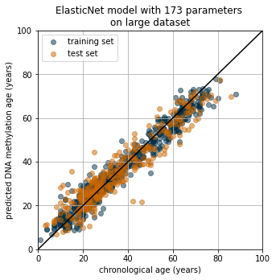

```python
plt.figure(figsize=(5,5))
plt.subplot(1, 1, 1)
plt.scatter(retransform_age(y_LR_train_large), retransform_age(LR_elnet_large.predict(X_LR_train_large)), color="#023047",
            alpha=0.5, label="training set")
plt.scatter(retransform_age(y_LR_test_large), retransform_age(LR_elnet_large.predict(X_LR_test_large)), color="#ca6702",
            alpha=0.5, label="test set")
plt.xlim(0,100)
plt.ylim(0,100)
plt.grid()
plt.xlabel("chronological age (years)")
plt.ylabel("predicted DNA methylation age (years)")
plt.title('ElasticNet model with %d parameters \non large dataset' % ((np.abs(LR_elnet_large.coef_) > 0).sum()+1))
plt.plot([0,100], [0,100], color="black")
plt.legend()
plt.show()
```

```python
print("------- Training set -------")
print("MAE (median absolute error): %.2f years" %
      np.median(np.abs(retransform_age(y_LR_train_large)-retransform_age(LR_elnet_large.predict(X_LR_train_large)))))
print("Pearson-correlation coefficient: %.2f" %
      np.corrcoef(retransform_age(y_LR_train_large), retransform_age(LR_elnet_large.predict(X_LR_train_large)))[0,1])
print()
print("------- Test set -------")
print("MAE (median absolute error): %.2f years" %
      np.median(np.abs(retransform_age(y_LR_test_large)-retransform_age(LR_elnet_large.predict(X_LR_test_large)))))
print("Pearson-correlation coefficient: %.2f" %
      np.corrcoef(retransform_age(y_LR_test_large), retransform_age(LR_elnet_large.predict(X_LR_test_large)))[0,1])
```

```
------- Training set -------
MAE (median absolute error): 2.54 years
Pearson-correlation coefficient: 0.98

------- Test set -------
MAE (median absolute error): 3.71 years
Pearson-correlation coefficient: 0.94
```

### Predictions on the validation set

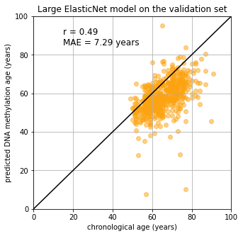

```python
# re-standardize validation data for the new training set
X_LR_validation_large = validation_data[probe_cols_to_keep_large_final].fillna(0)
X_LR_validation_large = scaler_large.transform(X_LR_validation_large)

# running the prediction and accessing model performance
y_LR_validation_predicted_transf_large = LR_elnet_large.predict(X_LR_validation_large)

MAE = np.median(np.abs(validation_data["age"]-retransform_age(y_LR_validation_predicted_transf_large)))
R = np.corrcoef(validation_data["age"], retransform_age(y_LR_validation_predicted_transf_large))[0,1]

plt.figure(figsize=(5,5))
plt.subplot(1, 1, 1)
plt.scatter(validation_data["age"], retransform_age(y_LR_validation_predicted_transf_large), color="#fca311", alpha=0.5)
plt.xlim(0,100)
plt.ylim(0,100)
plt.grid()
plt.xlabel("chronological age (years)")
plt.ylabel("predicted DNA methylation age (years)")
plt.title("Large ElasticNet model on the validation set")
plt.plot([0,100], [0,100], color="black")
plt.annotate("r = %.2f\nMAE = %.2f years" % (R, MAE), xy=(15,85), fontsize=12)
plt.show()
```

Surprisingly, fitting to a larger dataset resulted in worse performance on the validation dataset than what the original ElasticNet model provided.

This is where it becomes very apparent that you have to have a very detailed understanding of the data you work with and the processes that are used to create them. In our case, the validation dataset contained patients above the age of 50 years. However, additional dataset #1 had samples from very young (0-30 years) people, so adding these to the original training data is unlikely to improve performance on the validation dataset. On the other hand, additional dataset #2 had patients of ages 49-74 years, so this might give us a slight advantage.

Keep in mind that we still do not really know anything about the possible technical artifacts and batch effects that could influence the results.

As a last try, let's build a model with the original training data and only additional dataset #2.

### Data preparation and model building - our last try

```python
# finding overlapping probes in all datasets
probe_cols_to_keep_large2 = list(set(probe_cols_to_keep).intersection(set(methylation_data_additional2.columns)))

# fusing dataframes
methylation_data_all2 = pd.concat([methylation_data[list(probe_cols_to_keep_large)+["age", "gender"]],
                          methylation_data_additional2[list(probe_cols_to_keep_large)+["age", "gender"]]])

# getting rid of probes with too many missing values
probe_cols_to_keep_large_final2 = np.array(probe_cols_to_keep_large2)[list((methylation_data_all2[probe_cols_to_keep_large2].isnull().sum(axis=0) <= 10)[probe_cols_to_keep_large2])]
methylation_data_all2 = methylation_data_all2[list(probe_cols_to_keep_large_final2) + ["age", "gender"]]

# replacing remaining missing values with zeros
methylation_data_all2[probe_cols_to_keep_large_final2] = methylation_data_all2[probe_cols_to_keep_large_final2].fillna(0)

# transforming age
methylation_data_all2["age_transf"] = methylation_data_all2["age"].apply(transform_age)

# splitting into training and test sets
X_LR_train_large2, X_LR_test_large2, y_LR_train_large2, y_LR_test_large2 = train_test_split(
    methylation_data_all2[probe_cols_to_keep_large_final2],
    methylation_data_all2["age_transf"],
    test_size=0.33, random_state=42)

# standardization
scaler_large2 = StandardScaler()

scaler_large2.fit(X_LR_train_large2)
X_LR_train_large2 = scaler_large2.transform(X_LR_train_large2)
X_LR_test_large2 = scaler_large2.transform(X_LR_test_large2)
```

```python
# model fitting
LR_elnet_large2 = linear_model.ElasticNetCV()
LR_elnet_large2.fit(X_LR_train_large2, y_LR_train_large2)
```

```
ElasticNetCV()
```

### Predictions on training and test sets - our last try

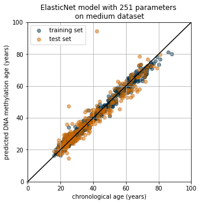

```python
plt.figure(figsize=(5,5))
plt.subplot(1, 1, 1)
plt.scatter(retransform_age(y_LR_train_large2), retransform_age(LR_elnet_large2.predict(X_LR_train_large2)), color="#023047",
            alpha=0.5, label="training set")
plt.scatter(retransform_age(y_LR_test_large2), retransform_age(LR_elnet_large2.predict(X_LR_test_large2)), color="#ca6702",
            alpha=0.5, label="test set")
plt.xlim(0,100)
plt.ylim(0,100)
plt.grid()
plt.xlabel("chronological age (years)")
plt.ylabel("predicted DNA methylation age (years)")
plt.title('ElasticNet model with %d parameters \non medium dataset' % ((np.abs(LR_elnet_large2.coef_) > 0).sum()+1))
plt.plot([0,100], [0,100], color="black")
plt.legend()
plt.show()
```

```python
print("------- Training set -------")
print("MAE (median absolute error): %.2f years" %
      np.median(np.abs(retransform_age(y_LR_train_large2)-retransform_age(LR_elnet_large2.predict(X_LR_train_large2)))))
print("Pearson-correlation coefficient: %.2f" %
      np.corrcoef(retransform_age(y_LR_train_large2), retransform_age(LR_elnet_large2.predict(X_LR_train_large2)))[0,1])
print()
print("------- Test set -------")
print("MAE (median absolute error): %.2f years" %
      np.median(np.abs(retransform_age(y_LR_test_large2)-retransform_age(LR_elnet_large2.predict(X_LR_test_large2)))))
print("Pearson-correlation coefficient: %.2f" %
      np.corrcoef(retransform_age(y_LR_test_large2), retransform_age(LR_elnet_large2.predict(X_LR_test_large2)))[0,1])
```

```
------- Training set -------
MAE (median absolute error): 1.42 years
Pearson-correlation coefficient: 0.99

------- Test set -------
MAE (median absolute error): 2.46 years
Pearson-correlation coefficient: 0.95
```

### Predictions on the validation set - our last try

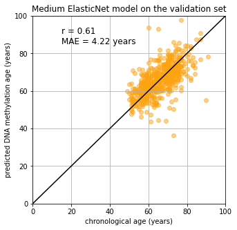

```python
# re-standardize validation data for the new training set
X_LR_validation_large2 = validation_data[probe_cols_to_keep_large_final2].fillna(0)
X_LR_validation_large2 = scaler_large2.transform(X_LR_validation_large2)

# running the prediction and accessing model performance
y_LR_validation_predicted_transf_large2 = LR_elnet_large2.predict(X_LR_validation_large2)

MAE = np.median(np.abs(validation_data["age"]-retransform_age(y_LR_validation_predicted_transf_large2)))
R = np.corrcoef(validation_data["age"], retransform_age(y_LR_validation_predicted_transf_large2))[0,1]

plt.figure(figsize=(5,5))
plt.subplot(1, 1, 1)
plt.scatter(validation_data["age"], retransform_age(y_LR_validation_predicted_transf_large2), color="#fca311", alpha=0.5)
plt.xlim(0,100)
plt.ylim(0,100)
plt.grid()
plt.xlabel("chronological age (years)")
plt.ylabel("predicted DNA methylation age (years)")
plt.title("Medium ElasticNet model on the validation set")
plt.plot([0,100], [0,100], color="black")
plt.annotate("r = %.2f\nMAE = %.2f years" % (R, MAE), xy=(15,85), fontsize=12)
plt.show()
```

Using a validation cohort from a single study is also unwise. It is possible that the given study has some special technical bias that results in poor predictions. It is always good practice to use both the largest possible training set and the largest possible validation set that you can find.

It depends on the given task whether you want to build a model that generalizes well to all imaginable cases (all tissue types, all measurement platforms, all age ranges, etc.) or you want to generate a model that works very precisely in specific cases (for example for whole blood samples, measured on the 27k Illumina platform).

## Conclusions

- Know your data!
  - Check datafiles by manually looking into them.
  - Be very careful when parsing strings.
  - Explore your data before model building, check distributions, look for missing values, find outliers.
  - Use standardization in most cases.
- Know your goal!
  - Do you want to build a model that generalizes to all cases "well enough"?
  - Or do you want to build a model that is extremely precise in a few well-defined cases?
- Make sure your model makes sense!
  - Do not fit a model with many parameters to a dataset of a few samples. - Avoid overfitting!
  - Use regularization to reduce the chance of overfitting.
- Be careful when interpreting predictive performance!
  - Make sure to test your models on unrelated, never-before-seen data. If you separate a test set from the original dataset and get good results, it is still possible that the model learned some technical artifact and not a real trend.
  - Always have a good understanding of the underlying data sources.
- Sometimes additional data can increase model performance way more than clever coding tricks. Take the time and effort to collect and preprocess as much data as you can.